# HW2

Akash Agrawal Bejarano & Oluwayimika Odejide

2/23/2023

## Question 1

```r
library(tidyverse)
library(dplyr)
x <- c(9,9,9,7,7,7,5,5,5,3,3,3,1,1,1)
y<- c(.07,.09,.08,.16,.17,.21,.49,.58,.53,1.22,1.15,1.07,2.84,2.57,3.10)
```

```r
linear <- lm(y ~ x)
summary(linear)
```

```
##
## Call:
## lm(formula = y ~ x)
##
## Residuals:
##     Min      1Q  Median      3Q     Max
## -0.5333 -0.4043 -0.1373  0.4157  0.8487
##
## Coefficients:
##             Estimate Std. Error t value Pr(>|t|)
## (Intercept)   2.5753     0.2487  10.354 1.20e-07 ***
## x            -0.3240     0.0433  -7.483 4.61e-06 ***
## ---
## Signif. codes:  0 '***' 0.001 '**' 0.01 '*' 0.05 '.' 0.1 ' ' 1
##
## Residual standard error: 0.4743 on 13 degrees of freedom
## Multiple R-squared:  0.8116, Adjusted R-squared:  0.7971
## F-statistic: 55.99 on 1 and 13 DF,  p-value: 4.611e-06
```

yhat <- 2.5753 -0.3240x

```r
anova(linear)
```

|  | Df | Sum Sq | Mean Sq | F value | Pr(>F) |
| --- | --- | --- | --- | --- | --- |
| x | 1 | 12.597120 | 12.5971200 | 55.99384 | 4.611199e-06 |
| Residuals | 13 | 2.924653 | 0.2249733 | NA | NA |

|  | Df <int> | Sum Sq <dbl> | Mean Sq <dbl> | F value <dbl> | Pr(>F) <dbl> |
| --- | --- | --- | --- | --- | --- |
| x | 1 | 12.597120 | 12.5971200 | 55.99384 | 4.611199e-06 |
| Residuals | 13 | 2.924653 | 0.2249733 | NA | NA |

2 rows

```r
f.value <- 55.994

f.critical <- qf(p = 0.025, df1 = 1, df2 = 13, lower.tail = FALSE)

print(paste("F value = ", f.value, "F Critical = ", f.critical))
```

```
## [1] "F value =  55.994 F Critical =  6.41425430025058"
```

```r
ifelse(f.value > f.critical, "Reject the null hypothesis", "Fail to reject the null hypothesis")
```

```
## [1] "Reject the null hypothesis"
```

Since we get an fvalue that is greater than the critical f statistic we reject the null hypothesis.

## Question 2

```r
X <- 0:9
Y <- c(98, 135, 162, 178,221, 232, 283, 300, 374, 395)
```

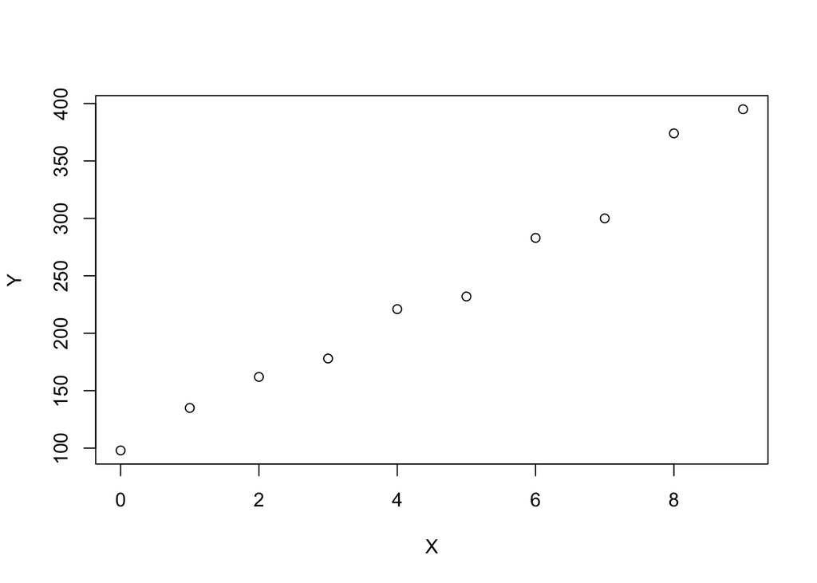

```r
plot(X, Y)
```

From the scatter plot above we can see a positive relationship which appers to be linear.

```r
library(MASS)
```

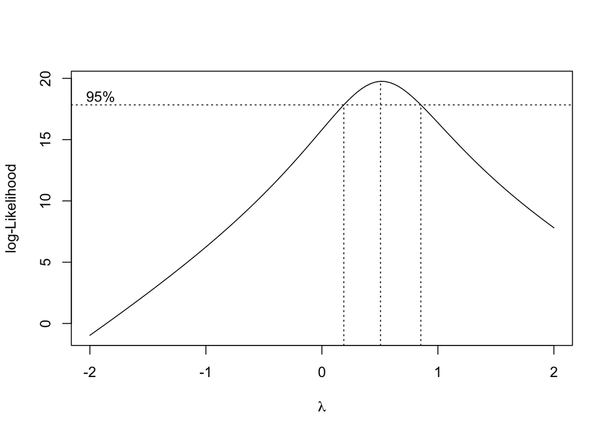

```r
box_cox <- boxcox(Y ~ X)
```

```r
lambda <- box_cox$x[which.max(box_cox$y)]
lambda
```

```
## [1] 0.5050505
```

```r
new_model <- lm(((Y^lambda-1)/lambda) ~ X)
new_model
```

```
##
## Call:
## lm(formula = ((Y^lambda - 1)/lambda) ~ X)
##
## Coefficients:
## (Intercept)            X
##      18.810        2.212
```

An Appropriate transformation of Y would be Y^(0.5050505)

```r
lambda.3 <- lm(((Y^.3 - 1) / .3) ~ X)
anova(lambda.3)
```

|  | Df | Sum Sq | Mean Sq | F value | Pr(>F) |
| --- | --- | --- | --- | --- | --- |
| X | 1 | 44.2624111 | 44.26241106 | 605.9159 | 7.926085e-09 |
| Residuals | 8 | 0.5844033 | 0.07305042 | NA | NA |

|  | Df <int> | Sum Sq <dbl> | Mean Sq <dbl> | F value <dbl> | Pr(>F) <dbl> |
| --- | --- | --- | --- | --- | --- |
| X | 1 | 44.2624111 | 44.26241106 | 605.9159 | 7.926085e-09 |
| Residuals | 8 | 0.5844033 | 0.07305042 | NA | NA |

2 rows

```r
lambda.4 <- lm(((Y^.4 - 1) / .4) ~ X)
anova(lambda.4)
```

|  | Df | Sum Sq | Mean Sq | F value | Pr(>F) |
| --- | --- | --- | --- | --- | --- |
| X | 1 | 129.929814 | 129.9298138 | 688.2315 | 4.788607e-09 |
| Residuals | 8 | 1.510304 | 0.1887879 | NA | NA |

|  | Df <int> | Sum Sq <dbl> | Mean Sq <dbl> | F value <dbl> | Pr(>F) <dbl> |
| --- | --- | --- | --- | --- | --- |
| X | 1 | 129.929814 | 129.9298138 | 688.2315 | 4.788607e-09 |
| Residuals | 8 | 1.510304 | 0.1887879 | NA | NA |

2 rows

```r
lambda.5 <- lm(((Y^.5 - 1) / .5) ~ X)
anova(lambda.5)
```

|  | Df | Sum Sq | Mean Sq | F value | Pr(>F) |
| --- | --- | --- | --- | --- | --- |
| X | 1 | 382.273310 | 382.2733097 | 728.3695 | 3.825876e-09 |
| Residuals | 8 | 4.198674 | 0.5248343 | NA | NA |

|  | Df <int> | Sum Sq <dbl> | Mean Sq <dbl> | F value <dbl> | Pr(>F) <dbl> |
| --- | --- | --- | --- | --- | --- |
| X | 1 | 382.273310 | 382.2733097 | 728.3695 | 3.825876e-09 |
| Residuals | 8 | 4.198674 | 0.5248343 | NA | NA |

2 rows

```r
lambda.6 <- lm(((Y^.6 - 1) / .6) ~ X)
anova(lambda.6)
```

|  | Df | Sum Sq | Mean Sq | F value | Pr(>F) |
| --- | --- | --- | --- | --- | --- |
| X | 1 | 1127.2465 | 1127.24647 | 711.2639 | 4.203454e-09 |
| Residuals | 8 | 12.6788 | 1.58485 | NA | NA |

|  | Df <int> | Sum Sq <dbl> | Mean Sq <dbl> | F value <dbl> | Pr(>F) <dbl> |
| --- | --- | --- | --- | --- | --- |
| X | 1 | 1127.2465 | 1127.24647 | 711.2639 | 4.203454e-09 |
| Residuals | 8 | 12.6788 | 1.58485 | NA | NA |

2 rows

```r
lambda.7 <- lm(((Y^.7 - 1) / .7) ~ X)
anova(lambda.7)
```

|  | Df | Sum Sq | Mean Sq | F value | Pr(>F) |
| --- | --- | --- | --- | --- | --- |
| X | 1 | 3331.43375 | 3331.433752 | 646.1102 | 6.14823e-09 |
| Residuals | 8 | 41.24911 | 5.156139 | NA | NA |

|  | Df <int> | Sum Sq <dbl> | Mean Sq <dbl> | F value <dbl> | Pr(>F) <dbl> |
| --- | --- | --- | --- | --- | --- |
| X | 1 | 3331.43375 | 3331.433752 | 646.1102 | 6.14823e-09 |
| Residuals | 8 | 41.24911 | 5.156139 | NA | NA |

2 rows

SSE = 0.584 when lamda = .3 suggested transformation is Y^0.3

SSE = 1.51 when lamda = .4 suggested transformation is Y^0.4

SSE = 4.20 when lamda = .5 suggested transformation is Y^0.5

SSE = 12.68 when lamda = .6 suggested transformation is Y^0.6

SSE = 41.2 when lamda = .7 suggested transformation is Y^0.7

```r
Y_trans <- lm(sqrt(Y) ~ X)
summary(Y_trans)
```

```
##
## Call:
## lm(formula = sqrt(Y) ~ X)
##
## Residuals:
##      Min       1Q   Median       3Q      Max
## -0.47447 -0.30811  0.01549  0.29541  0.46781
##
## Coefficients:
##             Estimate Std. Error t value Pr(>|t|)
## (Intercept) 10.26093    0.21290   48.20 3.80e-11 ***
## X            1.07629    0.03988   26.99 3.83e-09 ***
## ---
## Signif. codes:  0 '***' 0.001 '**' 0.01 '*' 0.05 '.' 0.1 ' ' 1
##
## Residual standard error: 0.3622 on 8 degrees of freedom
## Multiple R-squared:  0.9891, Adjusted R-squared:  0.9878
## F-statistic: 728.4 on 1 and 8 DF,  p-value: 3.826e-09
```

sqrt(yhat) <- 10.26093 + 1.07629X

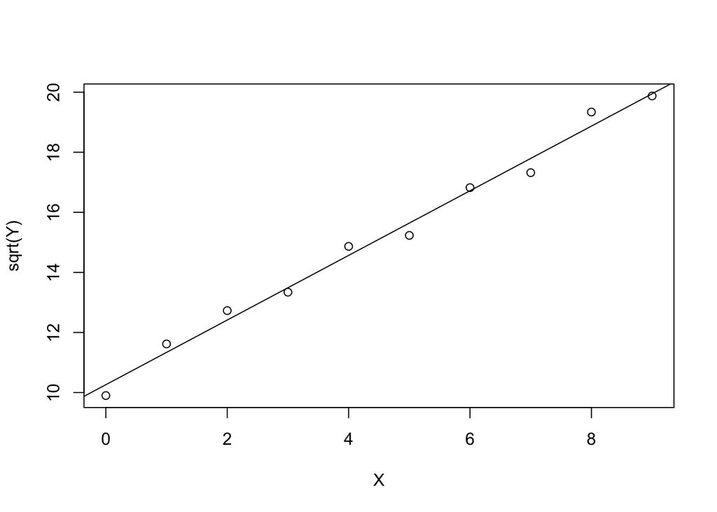

```r
plot(X, sqrt(Y))
abline(lm(sqrt(Y)~X))
```

The regression line appears to be a good fit for the transformed data

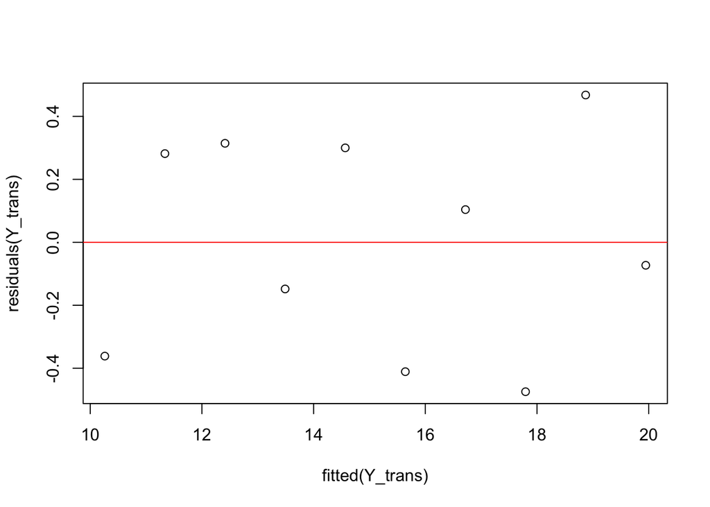

```r
plot(fitted(Y_trans), residuals(Y_trans))
abline(0,0, col = "red")
```

residual vs fitted plot shows signs of constant variance and no outliers in the data. Also shows signs of normality as there are equal number of data points above and below the 0 line in no specific pattern.

## Question 3

```r
A <- matrix(c(1, 4,
              2, 6,
              3, 8), ncol = 2, byrow = TRUE)


B <- matrix(c(1, 3,
              1, 4,
              2, 5), ncol = 2, byrow = TRUE)


C <- matrix(c(3, 8, 1,
              5, 4, 0), ncol = 3, byrow = TRUE)
```

```r
dim((A + B))
```

```
## [1] 3 2
```

```r
dim((A - B))
```

```
## [1] 3 2
```

```r
dim(A %*% C)
```

```
## [1] 3 3
```

```r
 dim(A %*% t(B))
```

```
## [1] 3 3
```

```r
dim(t(B)%*% A)
```

```
## [1] 2 2
```

## Question 4

```r
mtcars.fit <- lm(mpg ~ hp, data = mtcars)
mtcars.fit
```

```
##
## Call:
## lm(formula = mpg ~ hp, data = mtcars)
##
## Coefficients:
## (Intercept)           hp
##    30.09886     -0.06823
```

```r
newdf <- data.frame(hp = 62)
# Prediction Interval
predict(object = mtcars.fit, newdata = newdf, interval = "prediction") %>%
  cbind(newdf)
```

|  | fit | lwr | upr | hp |
| --- | --- | --- | --- | --- |
| 1 | 25.86871 | 17.66822 | 34.06919 | 62 |

|  | fit <dbl> | lwr <dbl> | upr <dbl> | hp <dbl> |
| --- | --- | --- | --- | --- |
| 1 | 25.86871 | 17.66822 | 34.06919 | 62 |

1 row

```r
# Confidence Interval
predict(object = mtcars.fit, newdata = newdf, interval = "confidence") %>%
  cbind(newdf)
```

|  | fit | lwr | upr | hp |
| --- | --- | --- | --- | --- |
| 1 | 25.86871 | 23.63082 | 28.10659 | 62 |

|  | fit <dbl> | lwr <dbl> | upr <dbl> | hp <dbl> |
| --- | --- | --- | --- | --- |
| 1 | 25.86871 | 23.63082 | 28.10659 | 62 |

1 row

Prediction Interval (17.6682, 34.06919)

Confidence Interval (23.6308, 28.1066)